# Tests for trends and association

2020-10-26

## Pearson’s Correlation Coefficient

Let’s look at the “cars” data available on R.

```r
library(MASS)
attach(cars)
head(cars)
```

```
##   speed dist
## 1     4    2
## 2     4   10
## 3     7    4
## 4     7   22
## 5     8   16
## 6     9   10
```

## Scatter plot

The scatter plot has an upward trend indicating positive trend!

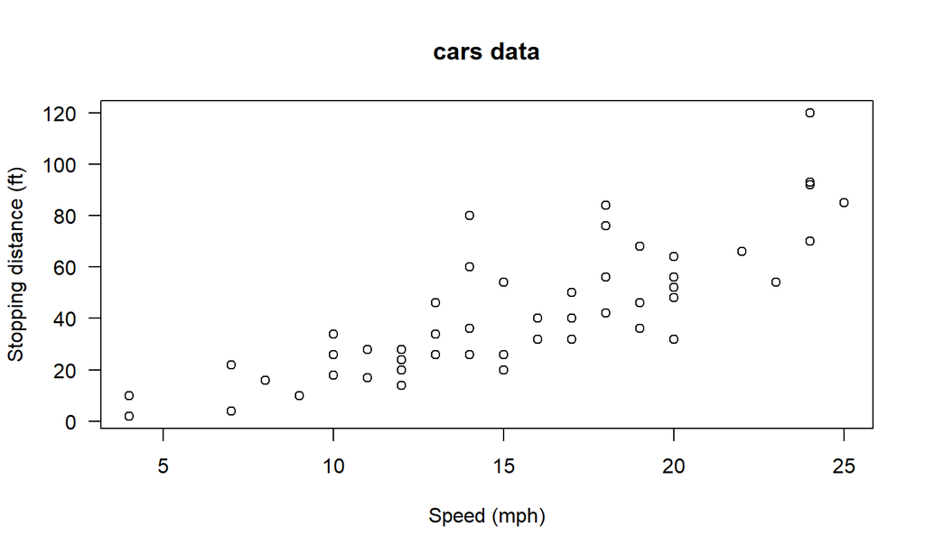

## Best fit line

We can try to fit a straight line or a curve to the scatter plot

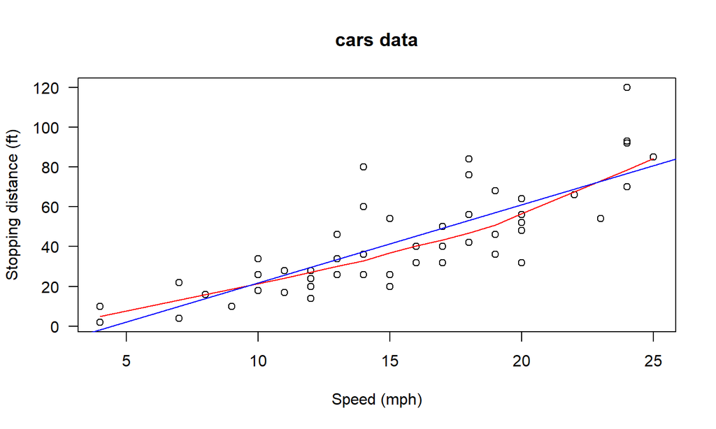

## Correlation

```r
cor(cars$speed,cars$dist)
```

```
## [1] 0.8068949
```

```r
cor.test(cars$speed,cars$dist)
```

```
##
##  Pearson's product-moment correlation
##
## data:  cars$speed and cars$dist
## t = 9.464, df = 48, p-value = 1.49e-12
## alternative hypothesis: true correlation is not equal to 0
## 95 percent confidence interval:
##  0.6816422 0.8862036
## sample estimates:
##       cor
## 0.8068949
```

## Log transform?

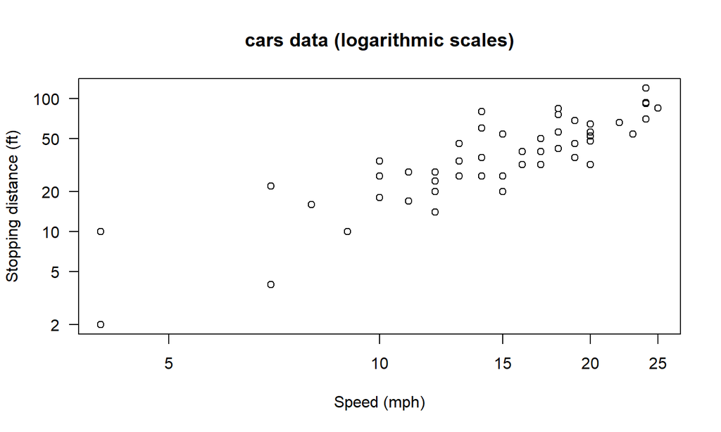

```r
plot(cars, xlab = "Speed (mph)", ylab = "Stopping distance (ft)",
     las = 1, log = "xy")
title(main = "cars data (logarithmic scales)")
```

## Does the correlation improve?

```r
cor(log(cars$speed),log(cars$dist))
```

```
## [1] 0.8562385
```

```r
cor.test(log(cars$speed),log(cars$dist))
```

```
##
##  Pearson's product-moment correlation
##
## data:  log(cars$speed) and log(cars$dist)
## t = 11.484, df = 48, p-value = 2.259e-15
## alternative hypothesis: true correlation is not equal to 0
## 95 percent confidence interval:
##  0.7587175 0.9162214
## sample estimates:
##       cor
## 0.8562385
```

## Remember

1. \(X\) and \(Y\) independent \(\Rightarrow\) \(\rho_{X,Y} = 0\), but not the other way round, unless \(X,Y\) are jointly normal.
2. Correlation \(\not \Rightarrow\) Causation. There could be a **lurking** variable, causing a **spurious** relationship.
3. Lots of hilarious examples in [Spurious Correlations Webpage](http://tylervigen.com/spurious-correlations)

## Example

- Here \(\rho_{X,Y} = 0\), but \(Y = X^2\), not independent, but not **linearly dependent**.

```r
x = c(-5,-4,-3,-2,-1,1,2,3,4,5);y = x^2
cor(x,y)
```

```
## [1] 0
```

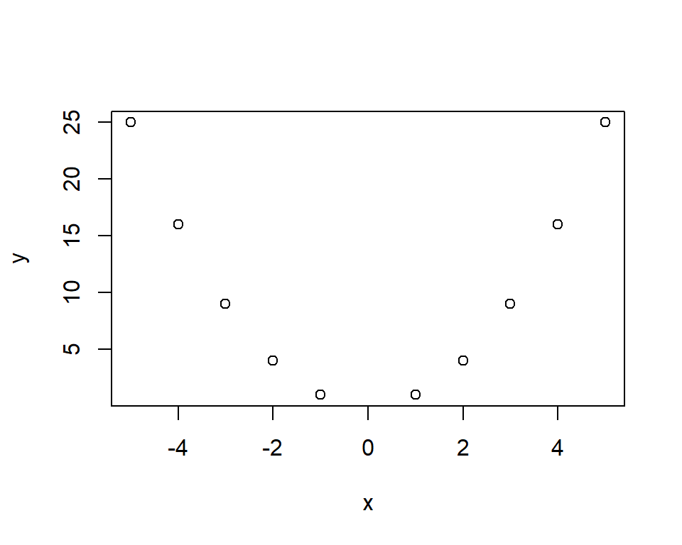

## Spearman’s correlation

## Motivation

- Pearson’s correlation coefficient measures only linear relationship.

```r
x = seq(1,7)
y = x^4
cor(x,y)
```

```
## [1] 0.8903055
```

```r
## same as cor(x,y,method="pearson")
cor(x,y,method="pearson")
```

```
## [1] 0.8903055
```

## Spearman’s rank correlation

- Spearman’s rank correlation: replace X, Y with their ranks.

```r
cor(rank(x),rank(y))
```

```
## [1] 1
```

```r
## same as cor(x,y,method="spearman")
cor(x,y,method="spearman")
```

```
## [1] 1
```

- Spearman’s \(r_s\) measure monotonic association. \(r_s = 1\) means X is a monotonically increasing function of Y.

## Transformation invariance

- Spearman’s \(r_s\) is preserved if we apply the same monotone order-preserving transformation to both \(X\) and \(Y\).
- Example: Apply log transformation to cars data, Pearson’s r will change, but Spearman’s \(r_s\) won’t!

```r
cor(cars$speed,cars$dist)
```

```
## [1] 0.8068949
```

```r
cor(log(cars$speed),log(cars$dist))
```

```
## [1] 0.8562385
```

## Spearman’s rank correlation

- As long as the transformation is monotone: \(f(x) = log(x)\), \(f(x) = x^2\).

```r
cor(cars$speed,cars$dist,method="spearman")
```

```
## [1] 0.8303568
```

```r
cor(log(cars$speed),log(cars$dist),method="spearman")
```

```
## [1] 0.8303568
```

```r
cor((cars$speed)^2,(cars$dist)^2,method="spearman")
```

```
## [1] 0.8303568
```

## Hypothesis test

```r
cor.test(cars$speed,cars$dist,method="spearman")
```

```
##
##  Spearman's rank correlation rho
##
## data:  cars$speed and cars$dist
## S = 3532.8, p-value = 8.825e-14
## alternative hypothesis: true rho is not equal to 0
## sample estimates:
##       rho
## 0.8303568
```

## Kendall’s tau

Kendall’s tau measures the association by measuring concordance or discordance in the data. If \(p_c\) and \(p_d\) denote the probability of concordance and discordance respectively: then Kendall’s coefficient \(\tau\) is defined as: \[ \tau = p_c - p_d \]

## Kendall’s tau

Kendall’s tau is related to Pearson’s product-moment correlation coefficient as: \[ \tau = \frac{2}{\pi} \arcsin(\rho) \]

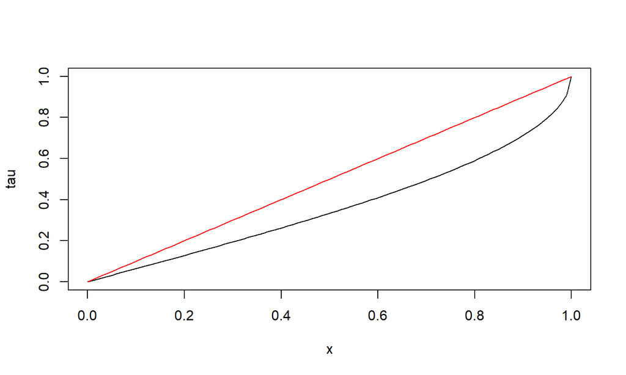

## Kendall’s tau

```r
cor(cars$speed,cars$dist,method="kendall")
```

```
## [1] 0.6689901
```

```r
cor(log(cars$speed),log(cars$dist),method="kendall")
```

```
## [1] 0.6689901
```

```r
cor((cars$speed)^2,(cars$dist)^2,method="kendall")
```

```
## [1] 0.6689901
```